# assignment-5

Alyssa Felix-Arreola

## 1. Correlating restaurant ratings and income levels

In this part, we'll use the census API to download household income data and explore how it correlates with restaurant review data.

### 1.1 Query the Census API

Use the `cenpy` package to download **median household income in the past 12 months** by census tract from the 2021 ACS 5-year data set for your county of interest.

You have two options to find the correct variable names:

- Search through: https://api.census.gov/data/2021/acs/acs5/variables.html
- Initialize an API connection and use the `.varslike()` function to search for the proper keywords

At the end of this step, you should have a pandas DataFrame holding the income data for all census tracts within the county being analyzed. Feel free to rename your variable from the ACS so it has a more meaningful name!

::: {.callout-caution} Some census tracts won't have any value because there are not enough households in that tract. The census will use a negative number as a default value for those tracts. You can safely remove those tracts from the analysis! :::

```python
# Data analysis
import geopandas as gpd
import numpy as np
import pandas as pd

# APIs
import requests

# Plotting
import seaborn as sns
from matplotlib import pyplot as plt
import holoviews as hv
import hvplot.pandas
```

```python
pd.options.display.max_columns = 999
pd.options.display.max_colwidth = 200
```

```python
# First step: import cenpy
import cenpy
```

```python
acs = cenpy.remote.APIConnection("ACSDT5Y2021")
```

```python
variables = [
    "NAME",
    "B19013_001E",  # total Median Household Income
]
```

```python
acs.geographies['fips']
```

|  | name | geoLevelDisplay | referenceDate | requires | wildcard | optionalWithWCFor |
| --- | --- | --- | --- | --- | --- | --- |
| 0 | us | 010 | 2021-01-01 | NaN | NaN | NaN |
| 1 | region | 020 | 2021-01-01 | NaN | NaN | NaN |
| 2 | division | 030 | 2021-01-01 | NaN | NaN | NaN |
| 3 | state | 040 | 2021-01-01 | NaN | NaN | NaN |
| 4 | county | 050 | 2021-01-01 | [state] | [state] | state |
| ... | ... | ... | ... | ... | ... | ... |
| 82 | public use microdata area | 795 | 2021-01-01 | [state] | [state] | state |
| 83 | zip code tabulation area | 860 | 2021-01-01 | NaN | NaN | NaN |
| 84 | school district (elementary) | 950 | 2021-01-01 | [state] | [state] | state |
| 85 | school district (secondary) | 960 | 2021-01-01 | [state] | [state] | state |
| 86 | school district (unified) | 970 | 2021-01-01 | [state] | [state] | state |

87 rows × 6 columns

```python
counties = cenpy.explorer.fips_table("COUNTY")
```

```python
# Trim to just Philadelphia
# Search for rows where name contains "Philadelphia"
counties.loc[ counties[3].str.contains("Philadelphia") ]
```

|  | 0 | 1 | 2 | 3 | 4 |
| --- | --- | --- | --- | --- | --- |
| 2294 | PA | 42 | 101 | Philadelphia County | H6 |

```python
philly_county_code = "101"
pa_state_code = "42"
```

```python
philly_data = acs.query(
    cols=variables,
    geo_unit="block group:*",
    geo_filter={"state": pa_state_code, "county": philly_county_code, "tract": "*"},
)


philly_data.head()
```

|  | NAME | B19013_001E | state | county | tract | block group |
| --- | --- | --- | --- | --- | --- | --- |
| 0 | Block Group 1, Census Tract 1.01, Philadelphia County, Pennsylvania | -666666666 | 42 | 101 | 000101 | 1 |
| 1 | Block Group 2, Census Tract 1.01, Philadelphia County, Pennsylvania | -666666666 | 42 | 101 | 000101 | 2 |
| 2 | Block Group 3, Census Tract 1.01, Philadelphia County, Pennsylvania | -666666666 | 42 | 101 | 000101 | 3 |
| 3 | Block Group 4, Census Tract 1.01, Philadelphia County, Pennsylvania | 97210 | 42 | 101 | 000101 | 4 |
| 4 | Block Group 5, Census Tract 1.01, Philadelphia County, Pennsylvania | 109269 | 42 | 101 | 000101 | 5 |

```python
for variable in variables:
    # Convert all variables EXCEPT for NAME
    if variable != "NAME":
        philly_data[variable] = philly_data[variable].astype(float)

# Filter out rows with negative values in the "B19013_001E" column
philly_data = philly_data[philly_data["B19013_001E"] >= 0]

# Display the DataFrame
philly_data.head()
```

|  | NAME | B19013_001E | state | county | tract | block group |
| --- | --- | --- | --- | --- | --- | --- |
| 3 | Block Group 4, Census Tract 1.01, Philadelphia County, Pennsylvania | 97210.0 | 42 | 101 | 000101 | 4 |
| 4 | Block Group 5, Census Tract 1.01, Philadelphia County, Pennsylvania | 109269.0 | 42 | 101 | 000101 | 5 |
| 5 | Block Group 1, Census Tract 1.02, Philadelphia County, Pennsylvania | 84211.0 | 42 | 101 | 000102 | 1 |
| 7 | Block Group 3, Census Tract 1.02, Philadelphia County, Pennsylvania | 198125.0 | 42 | 101 | 000102 | 3 |
| 8 | Block Group 4, Census Tract 1.02, Philadelphia County, Pennsylvania | 121920.0 | 42 | 101 | 000102 | 4 |

```python
acs.query(
    cols=variables,
    geo_unit="block group:*",
    geo_filter={"state": pa_state_code, "county": philly_county_code, "tract": "*"},
)
```

|  | NAME | B19013_001E | state | county | tract | block group |
| --- | --- | --- | --- | --- | --- | --- |
| 0 | Block Group 1, Census Tract 1.01, Philadelphia County, Pennsylvania | -666666666 | 42 | 101 | 000101 | 1 |
| 1 | Block Group 2, Census Tract 1.01, Philadelphia County, Pennsylvania | -666666666 | 42 | 101 | 000101 | 2 |
| 2 | Block Group 3, Census Tract 1.01, Philadelphia County, Pennsylvania | -666666666 | 42 | 101 | 000101 | 3 |
| 3 | Block Group 4, Census Tract 1.01, Philadelphia County, Pennsylvania | 97210 | 42 | 101 | 000101 | 4 |
| 4 | Block Group 5, Census Tract 1.01, Philadelphia County, Pennsylvania | 109269 | 42 | 101 | 000101 | 5 |
| ... | ... | ... | ... | ... | ... | ... |
| 1333 | Block Group 5, Census Tract 9892, Philadelphia County, Pennsylvania | -666666666 | 42 | 101 | 989200 | 5 |
| 1334 | Block Group 6, Census Tract 9892, Philadelphia County, Pennsylvania | -666666666 | 42 | 101 | 989200 | 6 |
| 1335 | Block Group 7, Census Tract 9892, Philadelphia County, Pennsylvania | -666666666 | 42 | 101 | 989200 | 7 |
| 1336 | Block Group 1, Census Tract 9893, Philadelphia County, Pennsylvania | -666666666 | 42 | 101 | 989300 | 1 |
| 1337 | Block Group 2, Census Tract 9893, Philadelphia County, Pennsylvania | -666666666 | 42 | 101 | 989300 | 2 |

1338 rows × 6 columns

### 1.2 Download census tracts from the Census and merge the data from part 1.1

- Download census tracts for the desired geography using the `pygris` package
- Merge the downloaded census tracts with the household income DataFrame

```python
import pygris
```

```python
pygris.block_groups?
```

[output not shown]

```python
philly_blockgroups = pygris.block_groups(
    state=pa_state_code, county=philly_county_code, year=2021
)
```

```python
philly = philly_blockgroups.merge(
    philly_data,
    left_on=["STATEFP", "COUNTYFP", "TRACTCE", "BLKGRPCE"],
    right_on=["state", "county", "tract", "block group"],
)

philly.head()
```

|  | STATEFP | COUNTYFP | TRACTCE | BLKGRPCE | GEOID | NAMELSAD | MTFCC | FUNCSTAT | ALAND | AWATER | INTPTLAT | INTPTLON | geometry | NAME | B19013_001E | state | county | tract | block group |
| --- | --- | --- | --- | --- | --- | --- | --- | --- | --- | --- | --- | --- | --- | --- | --- | --- | --- | --- | --- |
| 0 | 42 | 101 | 025700 | 3 | 421010257003 | Block Group 3 | G5030 | S | 89392 | 0 | +40.0717286 | -075.1919479 | POLYGON ((-75.19437 40.07059, -75.19419 40.07077, -75.19408 40.07088, -75.19285 40.07211, -75.19206 40.07290, -75.19083 40.07411, -75.18920 40.07317, -75.18958 40.07281, -75.18998 40.07248, -75.19... | Block Group 3, Census Tract 257, Philadelphia County, Pennsylvania | 53171.0 | 42 | 101 | 025700 | 3 |
| 1 | 42 | 101 | 001302 | 4 | 421010013024 | Block Group 4 | G5030 | S | 396274 | 60583 | +39.9436029 | -075.1858337 | POLYGON ((-75.19371 39.94226, -75.19268 39.94268, -75.19156 39.94313, -75.19150 39.94315, -75.19145 39.94320, -75.18872 39.94611, -75.18830 39.94641, -75.18730 39.94712, -75.18723 39.94718, -75.18... | Block Group 4, Census Tract 13.02, Philadelphia County, Pennsylvania | 136813.0 | 42 | 101 | 001302 | 4 |
| 2 | 42 | 101 | 020800 | 1 | 421010208001 | Block Group 1 | G5030 | S | 512635 | 0 | +40.0184109 | -075.1977311 | POLYGON ((-75.20606 40.01483, -75.20601 40.01490, -75.20597 40.01499, -75.20596 40.01501, -75.20585 40.01528, -75.20493 40.01502, -75.20242 40.01580, -75.20127 40.01719, -75.19985 40.01937, -75.19... | Block Group 1, Census Tract 208, Philadelphia County, Pennsylvania | 85333.0 | 42 | 101 | 020800 | 1 |
| 3 | 42 | 101 | 023600 | 2 | 421010236002 | Block Group 2 | G5030 | S | 282169 | 0 | +40.0470905 | -075.1953636 | POLYGON ((-75.19941 40.04647, -75.19881 40.04704, -75.19806 40.04774, -75.19651 40.04919, -75.19533 40.05054, -75.19449 40.05147, -75.19440 40.05160, -75.19433 40.05171, -75.19408 40.05163, -75.19... | Block Group 2, Census Tract 236, Philadelphia County, Pennsylvania | 89167.0 | 42 | 101 | 023600 | 2 |
| 4 | 42 | 101 | 010500 | 1 | 421010105001 | Block Group 1 | G5030 | S | 277095 | 0 | +39.9702909 | -075.2143967 | POLYGON ((-75.21777 39.97263, -75.21633 39.97279, -75.21389 39.97305, -75.21282 39.97317, -75.21221 39.97324, -75.21215 39.97301, -75.21211 39.97279, -75.21205 39.97251, -75.21186 39.97150, -75.21... | Block Group 1, Census Tract 105, Philadelphia County, Pennsylvania | 22705.0 | 42 | 101 | 010500 | 1 |

```python
# Rename columns
philly = philly.rename(
    columns={
        "B19013_001E": "MedianHouseholdIncome",  # Total
    }
)
```

### 1.3 Load the restaurants data

The Yelp dataset includes data for 7,350 restaurants across the city. Load the data from the `data/` folder and use the `latitude` and `longitude` columns to create a GeoDataFrame after loading the JSON data. Be sure to set the right CRS on when initializing the GeoDataFrame!

**Notes**

The JSON data is in a "records" format. To load it, you'll need to pass the following keywords:

- `orient='records'`
- `lines=True`

```python
import json
```

```python
restaurant_data = pd.read_json("~/miniforge3/envs/musa-550-fall-2023/assignment-5-alyssafelixa-main/data/restaurants_philly.json.gz", lines=True, orient='records')
# Display the DataFrame
restaurant_data.head()
```

|  | business_id | latitude | longitude | name | review_count | stars | categories |
| --- | --- | --- | --- | --- | --- | --- | --- |
| 0 | MTSW4McQd7CbVtyjqoe9mw | 39.955505 | -75.155564 | St Honore Pastries | 80 | 4.0 | Restaurants, Food, Bubble Tea, Coffee & Tea, Bakeries |
| 1 | MUTTqe8uqyMdBl186RmNeA | 39.953949 | -75.143226 | Tuna Bar | 245 | 4.0 | Sushi Bars, Restaurants, Japanese |
| 2 | ROeacJQwBeh05Rqg7F6TCg | 39.943223 | -75.162568 | BAP | 205 | 4.5 | Korean, Restaurants |
| 3 | QdN72BWoyFypdGJhhI5r7g | 39.939825 | -75.157447 | Bar One | 65 | 4.0 | Cocktail Bars, Bars, Italian, Nightlife, Restaurants |
| 4 | Mjboz24M9NlBeiOJKLEd_Q | 40.022466 | -75.218314 | DeSandro on Main | 41 | 3.0 | Pizza, Restaurants, Salad, Soup |

```python
restaurants_gdf = gpd.GeoDataFrame(restaurant_data,
                                   geometry=gpd.points_from_xy(restaurant_data['longitude'], restaurant_data['latitude']))

restaurants_gdf.crs = "EPSG:4326"

restaurants_gdf.head()
```

|  | business_id | latitude | longitude | name | review_count | stars | categories | geometry |
| --- | --- | --- | --- | --- | --- | --- | --- | --- |
| 0 | MTSW4McQd7CbVtyjqoe9mw | 39.955505 | -75.155564 | St Honore Pastries | 80 | 4.0 | Restaurants, Food, Bubble Tea, Coffee & Tea, Bakeries | POINT (-75.15556 39.95551) |
| 1 | MUTTqe8uqyMdBl186RmNeA | 39.953949 | -75.143226 | Tuna Bar | 245 | 4.0 | Sushi Bars, Restaurants, Japanese | POINT (-75.14323 39.95395) |
| 2 | ROeacJQwBeh05Rqg7F6TCg | 39.943223 | -75.162568 | BAP | 205 | 4.5 | Korean, Restaurants | POINT (-75.16257 39.94322) |
| 3 | QdN72BWoyFypdGJhhI5r7g | 39.939825 | -75.157447 | Bar One | 65 | 4.0 | Cocktail Bars, Bars, Italian, Nightlife, Restaurants | POINT (-75.15745 39.93982) |
| 4 | Mjboz24M9NlBeiOJKLEd_Q | 40.022466 | -75.218314 | DeSandro on Main | 41 | 3.0 | Pizza, Restaurants, Salad, Soup | POINT (-75.21831 40.02247) |

### 1.4 Add tract info for each restaurant

Do a spatial join to identify which census tract each restaurant is within. Make sure each dataframe has the same CRS!

At the end of this step, you should have a new dataframe with a column identifying the tract number for each restaurant.

```python
restaurants_gdf = restaurants_gdf.to_crs(philly.crs)

joined_data = gpd.sjoin(restaurants_gdf, philly, how="left", predicate="within")


joined_data.head()
```

|  | business_id | latitude | longitude | name | review_count | stars | categories | geometry | index_right | STATEFP | COUNTYFP | TRACTCE | BLKGRPCE | GEOID | NAMELSAD | MTFCC | FUNCSTAT | ALAND | AWATER | INTPTLAT | INTPTLON | NAME | MedianHouseholdIncome | state | county | tract | block group |
| --- | --- | --- | --- | --- | --- | --- | --- | --- | --- | --- | --- | --- | --- | --- | --- | --- | --- | --- | --- | --- | --- | --- | --- | --- | --- | --- | --- |
| 0 | MTSW4McQd7CbVtyjqoe9mw | 39.955505 | -75.155564 | St Honore Pastries | 80 | 4.0 | Restaurants, Food, Bubble Tea, Coffee & Tea, Bakeries | POINT (-75.15557 39.95550) | 763.0 | 42 | 101 | 000200 | 1 | 421010002001 | Block Group 1 | G5030 | S | 115923.0 | 0.0 | +39.9553611 | -075.1560966 | Block Group 1, Census Tract 2, Philadelphia County, Pennsylvania | 42308.0 | 42 | 101 | 000200 | 1 |
| 1 | MUTTqe8uqyMdBl186RmNeA | 39.953949 | -75.143226 | Tuna Bar | 245 | 4.0 | Sushi Bars, Restaurants, Japanese | POINT (-75.14323 39.95395) | 491.0 | 42 | 101 | 000102 | 3 | 421010001023 | Block Group 3 | G5030 | S | 48303.0 | 0.0 | +39.9533424 | -075.1439968 | Block Group 3, Census Tract 1.02, Philadelphia County, Pennsylvania | 198125.0 | 42 | 101 | 000102 | 3 |
| 2 | ROeacJQwBeh05Rqg7F6TCg | 39.943223 | -75.162568 | BAP | 205 | 4.5 | Korean, Restaurants | POINT (-75.16257 39.94322) | 513.0 | 42 | 101 | 001500 | 2 | 421010015002 | Block Group 2 | G5030 | S | 166161.0 | 0.0 | +39.9421477 | -075.1611428 | Block Group 2, Census Tract 15, Philadelphia County, Pennsylvania | 107292.0 | 42 | 101 | 001500 | 2 |
| 3 | QdN72BWoyFypdGJhhI5r7g | 39.939825 | -75.157447 | Bar One | 65 | 4.0 | Cocktail Bars, Bars, Italian, Nightlife, Restaurants | POINT (-75.15745 39.93982) | 587.0 | 42 | 101 | 001800 | 1 | 421010018001 | Block Group 1 | G5030 | S | 147883.0 | 0.0 | +39.9396209 | -075.1566638 | Block Group 1, Census Tract 18, Philadelphia County, Pennsylvania | 103125.0 | 42 | 101 | 001800 | 1 |
| 4 | Mjboz24M9NlBeiOJKLEd_Q | 40.022466 | -75.218314 | DeSandro on Main | 41 | 3.0 | Pizza, Restaurants, Salad, Soup | POINT (-75.21832 40.02246) | 537.0 | 42 | 101 | 021000 | 4 | 421010210004 | Block Group 4 | G5030 | S | 299302.0 | 55718.0 | +40.0229216 | -075.2183537 | Block Group 4, Census Tract 210, Philadelphia County, Pennsylvania | 86146.0 | 42 | 101 | 021000 | 4 |

### 1.5 Add income data to your restaurant data

Add the income data to your dataframe from the previous step, merging the census data based on the tract that each restaurant is within.

```python
restaurants_gdf = restaurants_gdf.to_crs(philly.crs)


restaurant_income_join = gpd.sjoin(restaurants_gdf, philly, how="left", predicate="within")


restaurant_income_join.head()
```

|  | business_id | latitude | longitude | name | review_count | stars | categories | geometry | index_right | STATEFP | COUNTYFP | TRACTCE | BLKGRPCE | GEOID | NAMELSAD | MTFCC | FUNCSTAT | ALAND | AWATER | INTPTLAT | INTPTLON | NAME | MedianHouseholdIncome | state | county | tract | block group |
| --- | --- | --- | --- | --- | --- | --- | --- | --- | --- | --- | --- | --- | --- | --- | --- | --- | --- | --- | --- | --- | --- | --- | --- | --- | --- | --- | --- |
| 0 | MTSW4McQd7CbVtyjqoe9mw | 39.955505 | -75.155564 | St Honore Pastries | 80 | 4.0 | Restaurants, Food, Bubble Tea, Coffee & Tea, Bakeries | POINT (-75.15557 39.95550) | 763.0 | 42 | 101 | 000200 | 1 | 421010002001 | Block Group 1 | G5030 | S | 115923.0 | 0.0 | +39.9553611 | -075.1560966 | Block Group 1, Census Tract 2, Philadelphia County, Pennsylvania | 42308.0 | 42 | 101 | 000200 | 1 |
| 1 | MUTTqe8uqyMdBl186RmNeA | 39.953949 | -75.143226 | Tuna Bar | 245 | 4.0 | Sushi Bars, Restaurants, Japanese | POINT (-75.14323 39.95395) | 491.0 | 42 | 101 | 000102 | 3 | 421010001023 | Block Group 3 | G5030 | S | 48303.0 | 0.0 | +39.9533424 | -075.1439968 | Block Group 3, Census Tract 1.02, Philadelphia County, Pennsylvania | 198125.0 | 42 | 101 | 000102 | 3 |
| 2 | ROeacJQwBeh05Rqg7F6TCg | 39.943223 | -75.162568 | BAP | 205 | 4.5 | Korean, Restaurants | POINT (-75.16257 39.94322) | 513.0 | 42 | 101 | 001500 | 2 | 421010015002 | Block Group 2 | G5030 | S | 166161.0 | 0.0 | +39.9421477 | -075.1611428 | Block Group 2, Census Tract 15, Philadelphia County, Pennsylvania | 107292.0 | 42 | 101 | 001500 | 2 |
| 3 | QdN72BWoyFypdGJhhI5r7g | 39.939825 | -75.157447 | Bar One | 65 | 4.0 | Cocktail Bars, Bars, Italian, Nightlife, Restaurants | POINT (-75.15745 39.93982) | 587.0 | 42 | 101 | 001800 | 1 | 421010018001 | Block Group 1 | G5030 | S | 147883.0 | 0.0 | +39.9396209 | -075.1566638 | Block Group 1, Census Tract 18, Philadelphia County, Pennsylvania | 103125.0 | 42 | 101 | 001800 | 1 |
| 4 | Mjboz24M9NlBeiOJKLEd_Q | 40.022466 | -75.218314 | DeSandro on Main | 41 | 3.0 | Pizza, Restaurants, Salad, Soup | POINT (-75.21832 40.02246) | 537.0 | 42 | 101 | 021000 | 4 | 421010210004 | Block Group 4 | G5030 | S | 299302.0 | 55718.0 | +40.0229216 | -075.2183537 | Block Group 4, Census Tract 210, Philadelphia County, Pennsylvania | 86146.0 | 42 | 101 | 021000 | 4 |

### 1.6 Make a plot of median household income vs. Yelp stars

Our dataset has the number of stars for each restaurant, rounded to the nearest 0.5 star. In this step, create a line plot that shows the average income value for each stars category (e.g., all restaurants with 1 star, 1.5 stars, 2 stars, etc.)

While their are multiple ways to do this, the [seaborn.lineplot()](https://seaborn.pydata.org/generated/seaborn.lineplot.html) is a great option. This can show the average value in each category as well as 95% uncertainty intervals. Use this function to plot the stars ("x") vs. average income ("y") for all of our restaurants, using the dataframe from last step. Be sure to format your figure to make it look nice!

**Question:** Is there a correlation between a restaurant's ratings and the income levels of its surrounding neighborhood?

[figure not shown]

```python
sns.set(style="whitegrid")


plt.figure(figsize=(12, 8))
plot = sns.lineplot(x="stars", y="MedianHouseholdIncome", data=restaurant_income_join, errorbar='sd', markers="o")

plot.set_xlabel("Yelp Stars")
plot.set_ylabel("Median Household Income")
plot.set_title("Median Household Income vs. Yelp Stars")


plt.show()
```

```python
##There is a correlation between Median Household Income and Yelp Stars as census tract with higher Median Household Income tend to have higher ratings for restaurants.
```

## 2. Fast food trends in Philadelphia

At the end of part 1, you should have seen a strong trend where higher income tracts generally had restaurants with better reviews. In this section, we'll explore the impact of fast food restaurants and how they might be impacting this trend.

**Hypothesis**

1. Fast food restaurants are predominantly located in areas with lower median income levels.
2. Fast food restaurants have worse reviews compared to typical restaurants.

If true, these two hypotheses could help to explain the trend we found in part 1. Let's dive in and test our hypotheses!

### 2.1 Identify fast food restaurants

The "categories" column in our dataset contains multiple classifications for each restaurant. One such category is "Fast Food". In this step, add a new column called "is_fast_food" that is `True` if the "categories" column contains the term "Fast Food" and `False` otherwise

```python
restaurant_income_join['is_fast_food'] = restaurant_income_join['categories'].str.contains('Fast Food', case=False)

print(restaurant_income_join.head())
```

```
              business_id   latitude  longitude                name  \
0  MTSW4McQd7CbVtyjqoe9mw  39.955505 -75.155564  St Honore Pastries
1  MUTTqe8uqyMdBl186RmNeA  39.953949 -75.143226            Tuna Bar
2  ROeacJQwBeh05Rqg7F6TCg  39.943223 -75.162568                 BAP
3  QdN72BWoyFypdGJhhI5r7g  39.939825 -75.157447             Bar One
4  Mjboz24M9NlBeiOJKLEd_Q  40.022466 -75.218314    DeSandro on Main

   review_count  stars                                             categories  \
0            80    4.0  Restaurants, Food, Bubble Tea, Coffee & Tea, Bakeries
1           245    4.0                      Sushi Bars, Restaurants, Japanese
2           205    4.5                                    Korean, Restaurants
3            65    4.0   Cocktail Bars, Bars, Italian, Nightlife, Restaurants
4            41    3.0                        Pizza, Restaurants, Salad, Soup

                     geometry  index_right STATEFP COUNTYFP TRACTCE BLKGRPCE  \
```

[output cut: 33 more lines]

```python
restaurant_income_join.head()
```

|  | business_id | latitude | longitude | name | review_count | stars | categories | geometry | index_right | STATEFP | COUNTYFP | TRACTCE | BLKGRPCE | GEOID | NAMELSAD | MTFCC | FUNCSTAT | ALAND | AWATER | INTPTLAT | INTPTLON | NAME | MedianHouseholdIncome | state | county | tract | block group | is_fast_food |
| --- | --- | --- | --- | --- | --- | --- | --- | --- | --- | --- | --- | --- | --- | --- | --- | --- | --- | --- | --- | --- | --- | --- | --- | --- | --- | --- | --- | --- |
| 0 | MTSW4McQd7CbVtyjqoe9mw | 39.955505 | -75.155564 | St Honore Pastries | 80 | 4.0 | Restaurants, Food, Bubble Tea, Coffee & Tea, Bakeries | POINT (-75.15557 39.95550) | 763.0 | 42 | 101 | 000200 | 1 | 421010002001 | Block Group 1 | G5030 | S | 115923.0 | 0.0 | +39.9553611 | -075.1560966 | Block Group 1, Census Tract 2, Philadelphia County, Pennsylvania | 42308.0 | 42 | 101 | 000200 | 1 | False |
| 1 | MUTTqe8uqyMdBl186RmNeA | 39.953949 | -75.143226 | Tuna Bar | 245 | 4.0 | Sushi Bars, Restaurants, Japanese | POINT (-75.14323 39.95395) | 491.0 | 42 | 101 | 000102 | 3 | 421010001023 | Block Group 3 | G5030 | S | 48303.0 | 0.0 | +39.9533424 | -075.1439968 | Block Group 3, Census Tract 1.02, Philadelphia County, Pennsylvania | 198125.0 | 42 | 101 | 000102 | 3 | False |
| 2 | ROeacJQwBeh05Rqg7F6TCg | 39.943223 | -75.162568 | BAP | 205 | 4.5 | Korean, Restaurants | POINT (-75.16257 39.94322) | 513.0 | 42 | 101 | 001500 | 2 | 421010015002 | Block Group 2 | G5030 | S | 166161.0 | 0.0 | +39.9421477 | -075.1611428 | Block Group 2, Census Tract 15, Philadelphia County, Pennsylvania | 107292.0 | 42 | 101 | 001500 | 2 | False |
| 3 | QdN72BWoyFypdGJhhI5r7g | 39.939825 | -75.157447 | Bar One | 65 | 4.0 | Cocktail Bars, Bars, Italian, Nightlife, Restaurants | POINT (-75.15745 39.93982) | 587.0 | 42 | 101 | 001800 | 1 | 421010018001 | Block Group 1 | G5030 | S | 147883.0 | 0.0 | +39.9396209 | -075.1566638 | Block Group 1, Census Tract 18, Philadelphia County, Pennsylvania | 103125.0 | 42 | 101 | 001800 | 1 | False |
| 4 | Mjboz24M9NlBeiOJKLEd_Q | 40.022466 | -75.218314 | DeSandro on Main | 41 | 3.0 | Pizza, Restaurants, Salad, Soup | POINT (-75.21832 40.02246) | 537.0 | 42 | 101 | 021000 | 4 | 421010210004 | Block Group 4 | G5030 | S | 299302.0 | 55718.0 | +40.0229216 | -075.2183537 | Block Group 4, Census Tract 210, Philadelphia County, Pennsylvania | 86146.0 | 42 | 101 | 021000 | 4 | False |

### 2.2 Calculate the median income for fast food and otherwise

Group by the "is_fast_food" column and calculate the median income for restaurants that are and are not fast food. You should find that income levels are lower in tracts with fast food.

*Note:* this is just an estimate, since we are calculating a median of median income values.

```python
median_income_by_fast_food = restaurant_income_join.groupby('is_fast_food')['MedianHouseholdIncome'].median()

# Display the result
print(median_income_by_fast_food)
```

```
is_fast_food
False    72500.0
True     55522.5
Name: MedianHouseholdIncome, dtype: float64
```

### 2.3 Load fast food review data

In the rest of part 2, we're going to run a sentiment analysis on the reviews for fast food restaurants. The review data for all fast food restaurants identified in part 2.1 is already stored in the `data/` folder. The data is stored as a JSON file and you can use `pandas.read_json` to load it.

**Notes**

The JSON data is in a "records" format. To load it, you'll need to pass the following keywords:

- `orient='records'`
- `lines=True`

```python
fast_food_reviews_path = '~/miniforge3/envs/musa-550-fall-2023/assignment-5-alyssafelixa-main/data/reviews_philly_fast_food.json.gz'


fast_food_reviews = pd.read_json(fast_food_reviews_path, orient='records', lines=True)

fast_food_reviews = fast_food_reviews.rename(columns={'stars': 'review_stars'})

print(fast_food_reviews.head())
```

```
              business_id               review_id  review_stars  \
0  kgMEBZG6rjkGeFzPaIM4MQ  E-yGr1OhsUBxNeUVLDVouA             1
1  FKrP06TDAKtxNG1vrRQcQQ  0IpFZoaY_RRNjha8Q_Wz6w             2
2  w9hS5x1F52Id-G1KTrAOZg  0KlwfaHZyvao41_3S47dyg             2
3  fr2qDm_mY1afIGMvqsKUCg  oKSUOq7pCQzyypFDSa1HoA             3
4  fr2qDm_mY1afIGMvqsKUCg  6SMUmb7Npwnq6AusxqOXzQ             5

                                                                                                                                                                                                      text
0  I know I shouldn't expect much but everything I asked for that was on the drive thru menu was not available. I was actually afraid of what I was going to get once I did get it. I saw the movie "wa...
1  Perfect place to go  if you like waiting 20 minutes at the counter and getting dirty looks from the waiters while you're waiting for service. My friend and I made the mistake of coming here after ...
2  Was not a fan of their cheesesteak. Their wiz sauce was mustard based and it was not terrible as a sandwich itself but mustard is not the flavor one expects or wants in a cheesesteak. It was overw...
3  Ok this is an aberration from my city foodie reviews but I figured I'll take the time and review some of the local establishments that I order from on a consistent base while working in Bensalem, ...
4  My family has been customers of George's for years. You pay for what you get. The quality of the food is premier and they don't hold back on portion size. Their cheesesteaks are amazing (chopped s...
```

```python
fast_food_reviews.head()
```

|  | business_id | review_id | review_stars | text |
| --- | --- | --- | --- | --- |
| 0 | kgMEBZG6rjkGeFzPaIM4MQ | E-yGr1OhsUBxNeUVLDVouA | 1 | I know I shouldn't expect much but everything I asked for that was on the drive thru menu was not available. I was actually afraid of what I was going to get once I did get it. I saw the movie "wa... |
| 1 | FKrP06TDAKtxNG1vrRQcQQ | 0IpFZoaY_RRNjha8Q_Wz6w | 2 | Perfect place to go if you like waiting 20 minutes at the counter and getting dirty looks from the waiters while you're waiting for service. My friend and I made the mistake of coming here after ... |
| 2 | w9hS5x1F52Id-G1KTrAOZg | 0KlwfaHZyvao41_3S47dyg | 2 | Was not a fan of their cheesesteak. Their wiz sauce was mustard based and it was not terrible as a sandwich itself but mustard is not the flavor one expects or wants in a cheesesteak. It was overw... |
| 3 | fr2qDm_mY1afIGMvqsKUCg | oKSUOq7pCQzyypFDSa1HoA | 3 | Ok this is an aberration from my city foodie reviews but I figured I'll take the time and review some of the local establishments that I order from on a consistent base while working in Bensalem, ... |
| 4 | fr2qDm_mY1afIGMvqsKUCg | 6SMUmb7Npwnq6AusxqOXzQ | 5 | My family has been customers of George's for years. You pay for what you get. The quality of the food is premier and they don't hold back on portion size. Their cheesesteaks are amazing (chopped s... |

### 2.4 Trim to the most popular fast food restaurants

There's too many reviews to run a sentiment analysis on all of them in a reasonable time. Let's trim our reviews dataset to the most popular fast food restaurants, using the list provided below.

You will need to get the "business_id" values for each of these restaurants from the restaurants data loaded in part 1.3. Then, trim the reviews data to include reviews only for those business IDs.

```python
popular_fast_food = [
    "McDonald's",
    "Wendy's",
    "Subway",
    "Popeyes Louisiana Kitchen",
    "Taco Bell",
    "KFC",
    "Burger King",
]
```

```python
popularfastfood_ids = restaurant_income_join[restaurant_income_join['name'].isin(popular_fast_food)]['business_id'].tolist()


popularfastfood_reviews = fast_food_reviews[fast_food_reviews['business_id'].isin(popularfastfood_ids)]


print(popularfastfood_reviews.head())
```

```
               business_id               review_id  review_stars  \
0   kgMEBZG6rjkGeFzPaIM4MQ  E-yGr1OhsUBxNeUVLDVouA             1
8   PjknD8uD_0tisZQbomiYoQ  6TqKBa-HDiq2_W_ip2AItA             5
13  kgMEBZG6rjkGeFzPaIM4MQ  NGaXI03qbtBLshjfJV4pbQ             3
17  LACylKxImNI29DKUQpWuHw  HHy9yIjW07VHUE6nXVbsVA             3
21  gq4zw-ru_rkZ2UBIanaZFQ  yMZTK5B_0SAdUXSrIkXrmA             1

                                                                                                                                                                                                       text
0   I know I shouldn't expect much but everything I asked for that was on the drive thru menu was not available. I was actually afraid of what I was going to get once I did get it. I saw the movie "wa...
8                                                                                       I am only giving 5 stars because the Shamrock Shake is back and delicious!! Too bad it's around only once a year ;(
13  Dirty bathrooms and very slow service, but I was pleased because they had a TV on with subtitles and the volume on, and it was turned to the news!  A good place to pass some time with a tasty Mc-s...
17                                                                                                        Burger King is an okay alternative to Mcdonalds. 6/10 Would recommend but idk about coming again.
21                                                         ive tried going here four times with no success because the drive tru takes so long that i have pulled away every single time. great job idiots!
```

```python
popularfastfood_reviews.head()
```

|  | business_id | review_id | review_stars | text |
| --- | --- | --- | --- | --- |
| 0 | kgMEBZG6rjkGeFzPaIM4MQ | E-yGr1OhsUBxNeUVLDVouA | 1 | I know I shouldn't expect much but everything I asked for that was on the drive thru menu was not available. I was actually afraid of what I was going to get once I did get it. I saw the movie "wa... |
| 8 | PjknD8uD_0tisZQbomiYoQ | 6TqKBa-HDiq2_W_ip2AItA | 5 | I am only giving 5 stars because the Shamrock Shake is back and delicious!! Too bad it's around only once a year ;( |
| 13 | kgMEBZG6rjkGeFzPaIM4MQ | NGaXI03qbtBLshjfJV4pbQ | 3 | Dirty bathrooms and very slow service, but I was pleased because they had a TV on with subtitles and the volume on, and it was turned to the news! A good place to pass some time with a tasty Mc-s... |
| 17 | LACylKxImNI29DKUQpWuHw | HHy9yIjW07VHUE6nXVbsVA | 3 | Burger King is an okay alternative to Mcdonalds. 6/10 Would recommend but idk about coming again. |
| 21 | gq4zw-ru_rkZ2UBIanaZFQ | yMZTK5B_0SAdUXSrIkXrmA | 1 | ive tried going here four times with no success because the drive tru takes so long that i have pulled away every single time. great job idiots! |

### 2.5 Run the emotions classifier on fast food reviews

Run a sentiment analysis on the reviews data from the previous step. Use the [DistilBERT model](https://huggingface.co/bhadresh-savani/distilbert-base-uncased-emotion) that can predict emotion labels (anger, fear, sadness, joy, love, and surprise). Transform the result from the classifier into a DataFrame so that you have a column for each of the emotion labels.

```python
import torch
from transformers import pipeline
```

```python
text_data = popularfastfood_reviews['text'].tolist()

model = "bhadresh-savani/distilbert-base-uncased-emotion"

emotion_classifier = pipeline(
    task="text-classification",
    model=model,
    tokenizer=model,
    truncation=True,
)

emotion_scores = emotion_classifier(text_data)


emotion_df = pd.DataFrame(emotion_scores)
emotion_df['text'] = text_data
```

```python
print(emotion_df.columns)
```

```
Index(['label', 'score', 'text'], dtype='object')
```

### 2.6 Identify the predicted emotion for each text

Use the pandas [idxmax()](https://pandas.pydata.org/pandas-docs/stable/reference/api/pandas.DataFrame.idxmax.html) to identify the predicted emotion for each review, and add this value to a new column called "prediction"

The predicted emotion has the highest confidence score across all emotion labels for a particular label.

```python
emotion_df_no_duplicates = emotion_df.drop_duplicates(subset='text')


emotion_pivot = emotion_df_no_duplicates.pivot(index='text', columns='label', values='score').reset_index()


emotion_pivot.columns.name = None  # Remove the 'label' name for columns


emotion_pivot.head()
```

|  | text | anger | fear | joy | love | sadness | surprise |
| --- | --- | --- | --- | --- | --- | --- | --- |
| 0 | "Meh. I've experienced better." That's what Yelp! relates in words to the 2-star rating. Says it all, as I'm eating my veggie foot long. \n\nDon't get me wrong. The staff was fine. There was ... | NaN | NaN | 0.997238 | NaN | NaN | NaN |
| 1 | "No burgers in Burger King!" I went to this Burger King last week because they recently advertised that they had hot dogs, and my mom was wanting a dog. I ordered a hot dog and the cashier says, "... | NaN | NaN | NaN | 0.881434 | NaN | NaN |
| 2 | "Open 24 hours"... or when we feel like it. That's the way it seems to be in some of these 'neighborhoods'. Pulled in around 7am on a rainy Monday morning... didn't feel like coming to work? Answe... | NaN | NaN | NaN | NaN | 0.994735 | NaN |
| 3 | "Why the fuck you add salad dressing to the bag when you ain't even add the fries?!" Three women yelling at each other for 30 minutes while we were in the drive through waiting for cold ass food | 0.997625 | NaN | NaN | NaN | NaN | NaN |
| 4 | $.69 for any size coffee you say? Breakfast sandwiches comprised of egg, meat and cheese crammed between two syrupy pancakes? Granted eating here 3 times a day will take 10 years off your life, ... | NaN | NaN | NaN | NaN | 0.898883 | NaN |

```python
popularfastfood_emotions = pd.merge(popularfastfood_reviews, emotion_pivot, on='text', how='left')

popularfastfood_emotions['prediction'] = merged_df[['anger', 'fear', 'sadness', 'joy', 'surprise', 'love']].idxmax(axis=1)

popularfastfood_emotions.head()
```

|  | business_id | review_id | review_stars | text | anger | fear | joy | love | sadness | surprise | prediction |
| --- | --- | --- | --- | --- | --- | --- | --- | --- | --- | --- | --- |
| 0 | kgMEBZG6rjkGeFzPaIM4MQ | E-yGr1OhsUBxNeUVLDVouA | 1 | I know I shouldn't expect much but everything I asked for that was on the drive thru menu was not available. I was actually afraid of what I was going to get once I did get it. I saw the movie "wa... | NaN | NaN | NaN | NaN | 0.733872 | NaN | sadness |
| 1 | PjknD8uD_0tisZQbomiYoQ | 6TqKBa-HDiq2_W_ip2AItA | 5 | I am only giving 5 stars because the Shamrock Shake is back and delicious!! Too bad it's around only once a year ;( | NaN | NaN | 0.998759 | NaN | NaN | NaN | joy |
| 2 | kgMEBZG6rjkGeFzPaIM4MQ | NGaXI03qbtBLshjfJV4pbQ | 3 | Dirty bathrooms and very slow service, but I was pleased because they had a TV on with subtitles and the volume on, and it was turned to the news! A good place to pass some time with a tasty Mc-s... | NaN | NaN | 0.998563 | NaN | NaN | NaN | joy |
| 3 | LACylKxImNI29DKUQpWuHw | HHy9yIjW07VHUE6nXVbsVA | 3 | Burger King is an okay alternative to Mcdonalds. 6/10 Would recommend but idk about coming again. | NaN | NaN | 0.996928 | NaN | NaN | NaN | joy |
| 4 | gq4zw-ru_rkZ2UBIanaZFQ | yMZTK5B_0SAdUXSrIkXrmA | 1 | ive tried going here four times with no success because the drive tru takes so long that i have pulled away every single time. great job idiots! | NaN | NaN | 0.985421 | NaN | NaN | NaN | joy |

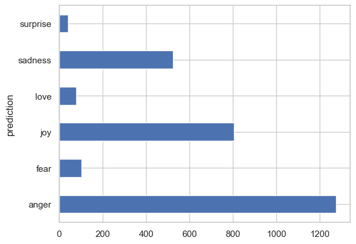

```python
popularfastfood_emotions.groupby("prediction").size().plot(kind='barh');
```